# 3.2 — Stackelberg Competition — Practice Problems

Solutions

ECON 326 — Spring 2023

Return to the example from lessons 2.2 and 2.3: Firm 1 and Firm 2 have a constant $MC=AC=8$. The market (inverse) demand curve is given by:

$$\begin{aligned}
P&=200-2Q\\
Q&=q_1+q_2\\
\end{aligned}$$

1. Suppose Firm 1 is the Leader and Firm 2 is the follower. Find the Stackelberg Nash Equilibrium quantity for each firm. Hint, the Cournot reaction functions you found before were:

$$\begin{aligned}
q_1^\star & = 48 - 0.5 * q_2\\
q_2^\star & = 48 - 0.5 * q_1\\
\end{aligned}$$

Substitute follower’s reaction function into market (inverse) demand function

- Find $MR$ for Firm 1 from market demand

$$MR_{1}=104-2q_{1}$$

Firm 2 will respond:

$$\begin{align*}
q_2^*&=48-0.5q_{1}\\
q_2^*&=48-0.5(48)\\
q_2^*&=48-24\\
q_2^*&=24\\
\end{align*}$$

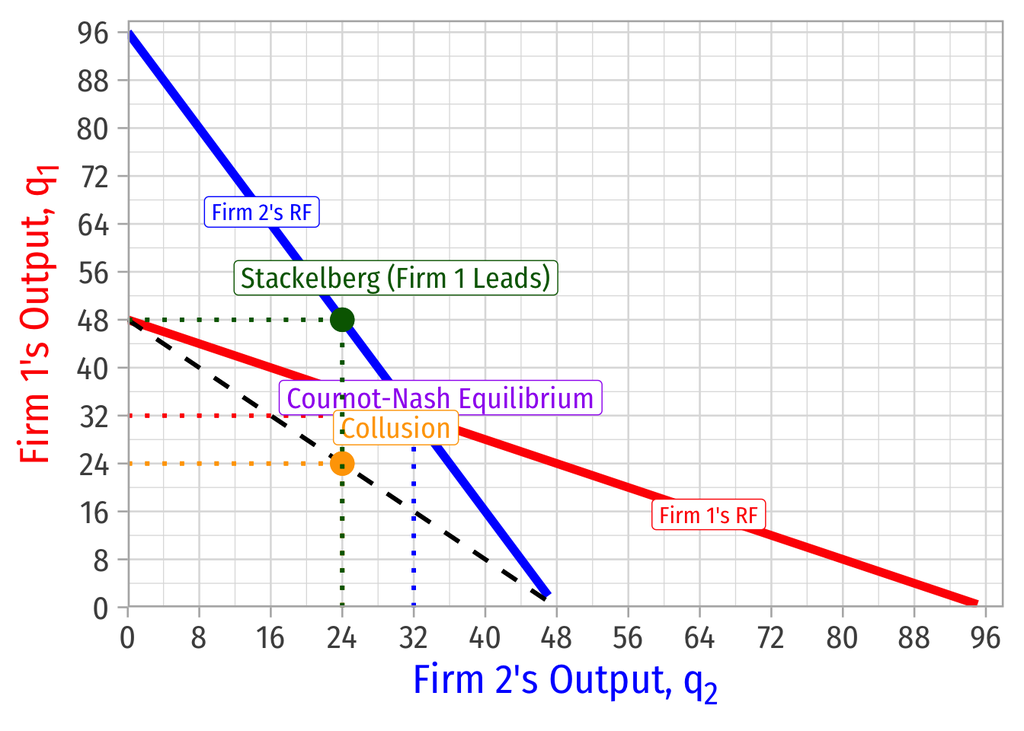

2. Find the market price.

With $q^*_{1}=48$ and $q^*_2=24$, this sets a market price of

$$\begin{align*}
P&=200-2Q\\
P&=200-2(72)\\
P&=56\\
\end{align*}$$

3. Find the profit for each firm. Compare their profits under Stackelberg competition to their profits under Cournot competition (from lesson 2.2).

Profit for Firm 1 is

$$\begin{align*}
\pi_{1}&=q_{1}(P-c)\\
\pi_{1}&=48(56-8)\\
\pi_{1}&=\$2,304\\
\end{align*}$$

Profit for Firm 2 is

$$\begin{align*}
\pi_{2}&=q_{2}(P-c)\\
\pi_{2}&=24(56-8)\\
\pi_{2}&=\$1,152\\
\end{align*}$$

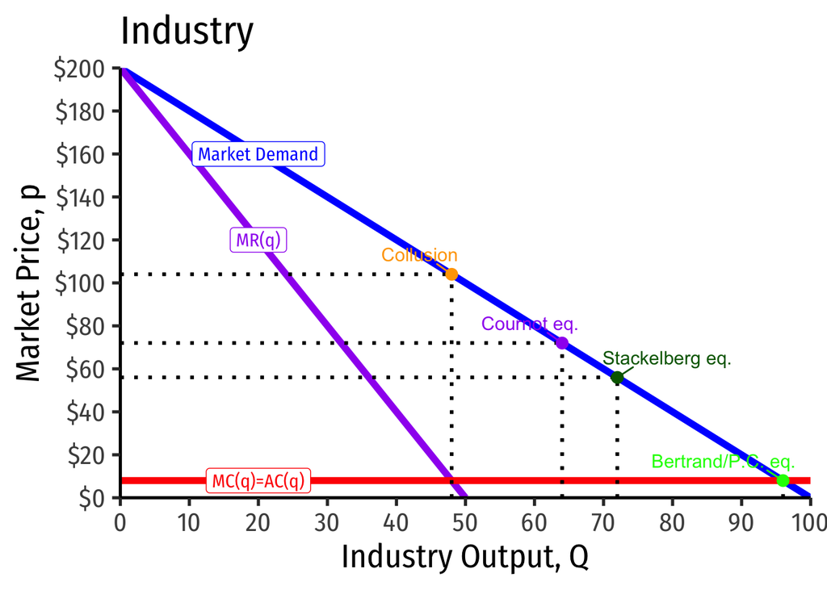

Compared to the Cournot equilibrium where each firm produces 32, setting a market price of $72, and a profit of $2048 for each firm, under Stackelberg competition, Firm 1 produces more than Cournot and earns higher than Cournot profits, while Firm 2 produces less than Cournot and earns less profit.